# Country Level Predictor Standardization

Rachel Ledig

4/20/2021

```r
aei_no_std <- read.csv("/Volumes/RachelExternal/Thesis/Data_upload_for_CL/AEI_NoStd.csv") #some data
source("/Volumes/RachelExternal/Thesis/Thesis/Thesis_Functions.R") #some functions
```

# Standardization

We’ve got a lot of things here to log, scale or center.

What do I mean by scaling or centering?

**Normalizing**: Shifting the range of the predictor between [0,1] using the formula: $\frac{y_i-min(y)}{max(y)-min(y)}$. This is useful because for some predictors it is helpul to have a notion of how big or small they are with the constraints of 0 and 1.

**Centering**: Centering the mean of the predictor on 0 or 1 using the formula: $\frac{y_i-mean(y)}{2sd(y)}$. The classic with a twist. By using 2 standard deviations, 95% of the data is contained within 2 sd, convient.

Why must I do this?

Well, a couple of reasons. First and foremost it makes the specification of priors easier, as the distribution of the parameter already centered around the mean and most of the data points are contained within one standard deviation to each side. Another reason is that it makes the interpretation of the coeficients a bit easier, as you can clearly tell which have positive or negative effects.

A lot of these predictors I assume accumulate exponentially. Population, Income and total GDP are obvious ones. Some others seem to be exponential as well, given the distribution of their histograms, such as majority of the crop fractions. However, variables like irrperc/irrfrac and the crop fractions have a hard time being transformed using a log transformation because they are so zero inflated. As Log(0) = -Inf, this causes a lot of problems. I will keep them in their original scale.

```r
#these functions are coming from Thesis_Functions.R, loaded in the beginning
aei_std <-
  aei_no_std %>%
  select(-c(20, 21,24,28)) %>%
  mutate(across(c(17:19, 23), log)) %>%
  #centering by dividing by 2sd, so that 95% of the distribution is from [-1,1]
  mutate(across(c(8, 17:19, 20:23, 25:51), centered)) %>%
  mutate(across(c(24), normalized))

summary(aei_std)
```

```
##        X              ISO                 year        country
##  Min.   :   1.0   Length:3003        Min.   :1910   Length:3003
##  1st Qu.: 751.5   Class :character   1st Qu.:1940   Class :character
##  Median :1502.0   Mode  :character   Median :1970   Mode  :character
##  Mean   :1502.0                      Mean   :1964
##  3rd Qu.:2252.5                      3rd Qu.:1990
##  Max.   :3003.0                      Max.   :2005
##
##        ID            aei_ha           yearcount        area_km
##  Min.   :  1.0   Min.   :       0   Min.   : 0.00   Min.   :-0.17326
##  1st Qu.: 62.0   1st Qu.:       0   1st Qu.:30.00   1st Qu.:-0.16998
##  Median :125.0   Median :   12852   Median :60.00   Median :-0.14599
##  Mean   :125.5   Mean   :  804385   Mean   :54.23   Mean   : 0.00000
##  3rd Qu.:187.0   3rd Qu.:  200700   3rd Qu.:80.00   3rd Qu.:-0.04524
##  Max.   :400.0   Max.   :64646000   Max.   :95.00   Max.   : 4.45988
##                                                     NA's   :260
##     irrperc            irrfrac        four_regions       eight_regions
##  Min.   : 0.00000   Min.   :0.00000   Length:3003        Length:3003
##  1st Qu.: 0.00586   1st Qu.:0.00006   Class :character   Class :character
##  Median : 0.21376   Median :0.00214   Mode  :character   Mode  :character
##  Mean   : 1.67096   Mean   :0.01671
##  3rd Qu.: 1.53916   3rd Qu.:0.01539
##  Max.   :37.41152   Max.   :0.37412
##  NA's   :260        NA's   :260
##  six_regions           Latitude        Longitude       World.bank.region
##  Length:3003        Min.   :-42.00   Min.   :-175.00   Length:3003
##  Class :character   1st Qu.:  4.00   1st Qu.:  -9.50   Class :character
##  Mode  :character   Median : 17.05   Median :  20.00   Mode  :character
##                     Mean   : 18.81   Mean   :  20.06
##                     3rd Qu.: 39.75   3rd Qu.:  48.00
##                     Max.   : 65.00   Max.   : 179.14
##                     NA's   :650      NA's   :650
##    population          income            GDPtot           medHumid
##  Min.   :-1.5488   Min.   :-1.0451   Min.   :-1.6321   Min.   :-0.61723
##  1st Qu.:-0.3062   1st Qu.:-0.3945   1st Qu.:-0.3408   1st Qu.:-0.39036
##  Median : 0.0756   Median :-0.0663   Median : 0.0308   Median :-0.03177
##  Mean   : 0.0000   Mean   : 0.0000   Mean   : 0.0000   Mean   : 0.00000
##  3rd Qu.: 0.3193   3rd Qu.: 0.3491   3rd Qu.: 0.3425   3rd Qu.: 0.27096
##  Max.   : 1.3576   Max.   : 1.5759   Max.   : 1.3636   Max.   : 4.45760
##  NA's   :650       NA's   :663       NA's   :663       NA's   :143
```

[output cut: 49 more lines]

```
##  Min.   :-0.07489   Min.   :-0.11676   Min.   :-0.12594   Min.   :-0.08894
##  1st Qu.:-0.07489   1st Qu.:-0.11676   1st Qu.:-0.12594   1st Qu.:-0.08894
##  Median :-0.07489   Median :-0.11676   Median :-0.12594   Median :-0.08894
##  Mean   : 0.00000   Mean   : 0.00000   Mean   : 0.00000   Mean   : 0.00000
##  3rd Qu.:-0.03256   3rd Qu.:-0.02077   3rd Qu.:-0.02253   3rd Qu.:-0.07576
##  Max.   :15.38724   Max.   :18.68659   Max.   :18.88651   Max.   :13.06397
##  NA's   :143        NA's   :143        NA's   :143        NA's   :143
##   Sugarcane.1          Others.1        Managed_Grasslands.1
##  Min.   :-0.14834   Min.   :-0.15897   Min.   :-0.1412
##  1st Qu.:-0.14834   1st Qu.:-0.15076   1st Qu.:-0.1412
##  Median :-0.13447   Median :-0.07690   Median :-0.1096
##  Mean   : 0.00000   Mean   : 0.00000   Mean   : 0.0000
##  3rd Qu.:-0.02984   3rd Qu.: 0.01846   3rd Qu.:-0.0179
##  Max.   : 8.15040   Max.   :19.51600   Max.   :12.6142
##  NA's   :143        NA's   :143        NA's   :143
```

```r
#write.csv(aei_std, "/Volumes/RachelExternal/Thesis/Data_upload_for_CL/AEI_Std.csv")
```

# Histograms

Lets plot these before and after being transformed.

## Main Predictors

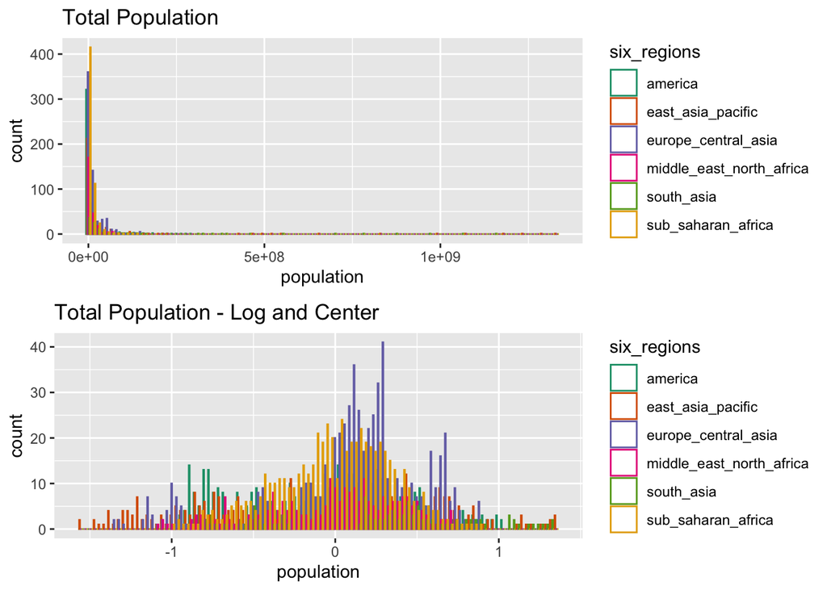

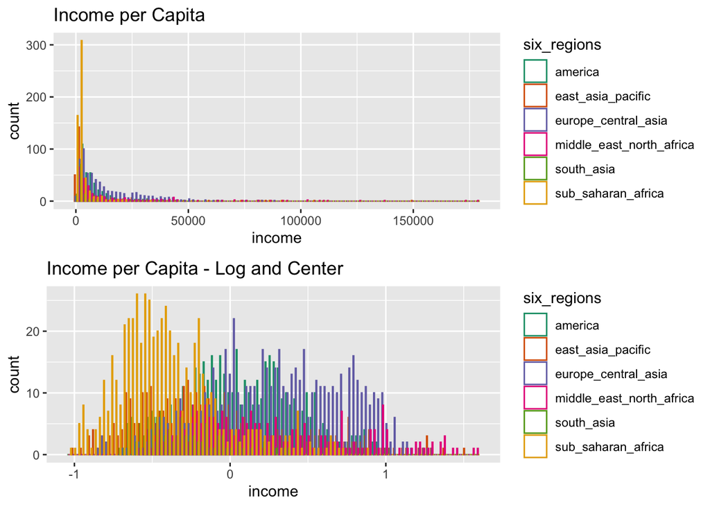

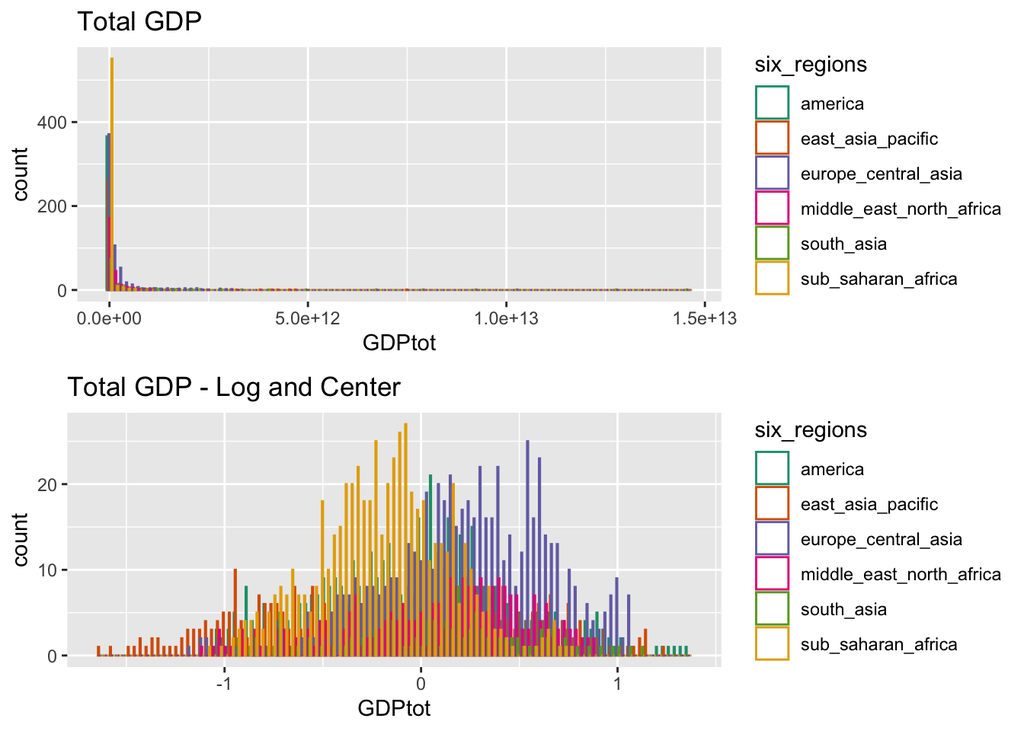

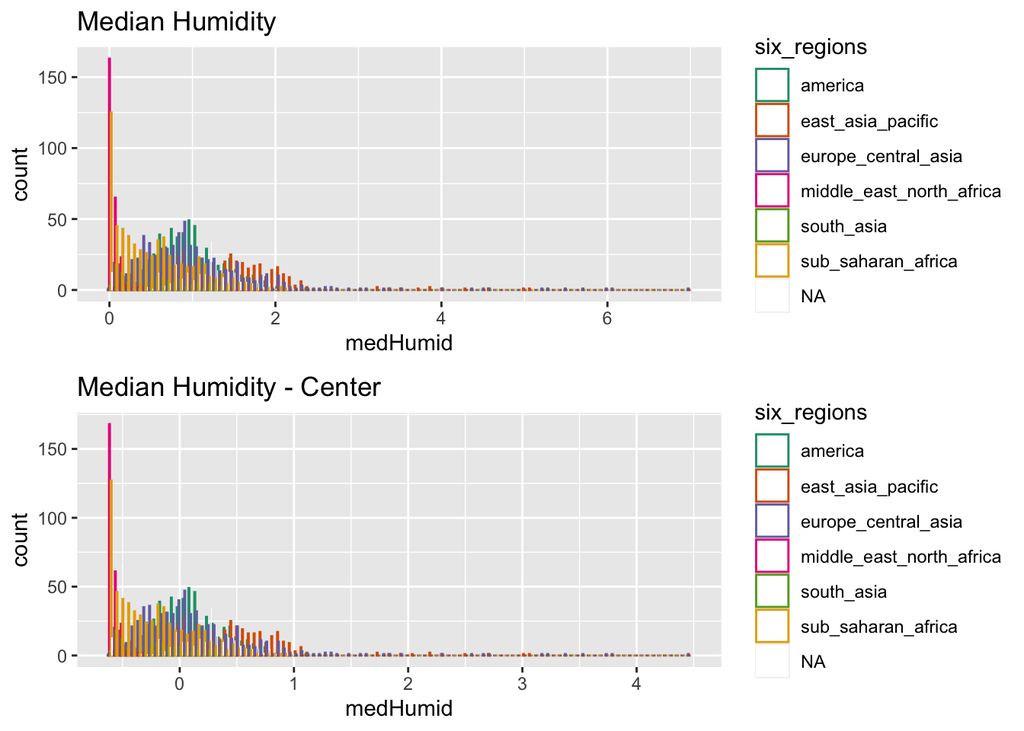

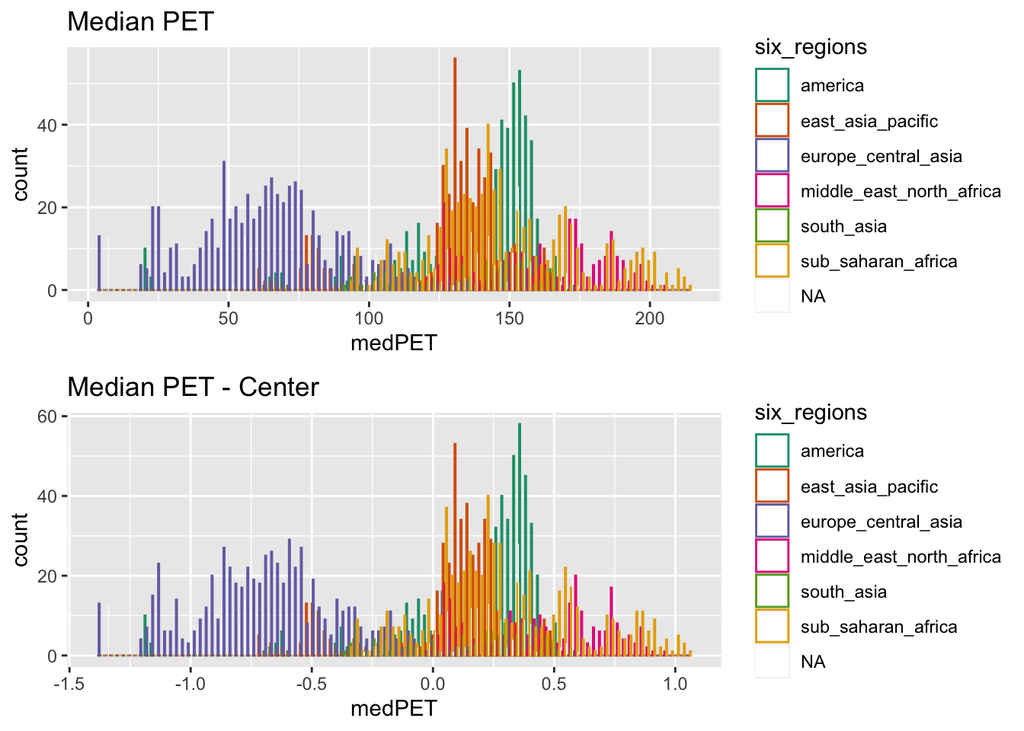

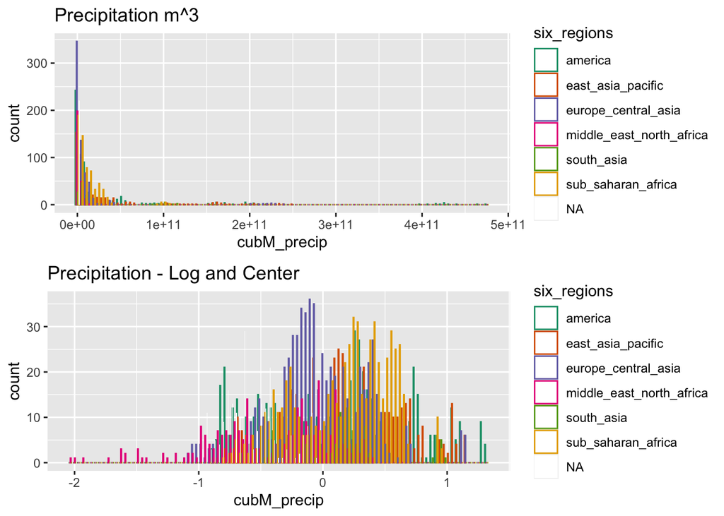

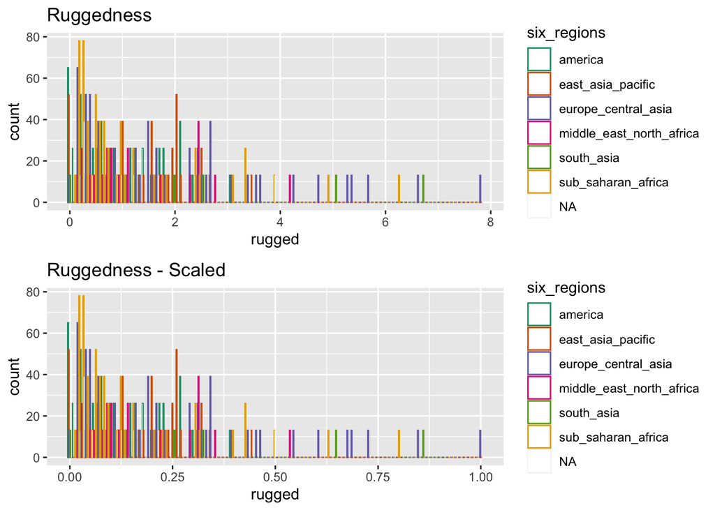

The transformations of the predictors look good, and those variables that were logged and then centered look great, much more normally distributed

## Crop Fractions

What about crop fractions?